# Rプログラミング入門 GISによる可視化

Cho（ztempest0218@gmail.com）

Last Updated: 2026-06-12

**今回の内容**

- GISとは何か
  - 地図データの拡張子、座標参照系（CRS）を確認する
- 地図データを読み込む（`sf`パッケージ）
- 少子化を可視化する（面データ）
- 鉄道を可視化する（線データと点データ）

**今回使用するデータ**

1. 国土数値情報 行政区域データ（N03）（rawデータ）
2. 国土数値情報 鉄道データ（N02）（rawデータ）
3. ssdse_birth_rate_2012_2023.rds（SSDSEから抽出する少子化データ）
4. japan_prefecture_2026.rds（処理済み都道府県地図データ）
5. japan_railway_2025.rds / japan_station_2025.rds（処理済み鉄道データ）

rawデータは[国土数値情報ダウンロードサイト](https://nlftp.mlit.go.jp/ksj/index.html)からもダウンロードできる。処理済みデータは授業用ページからダウンロードしてください。

# 1 GISとは

GIS とは Geographic Information System の略であり、日本語では地理情報システムと呼ばれる。簡単に言えば、**場所に関する情報を扱う仕組み**である。

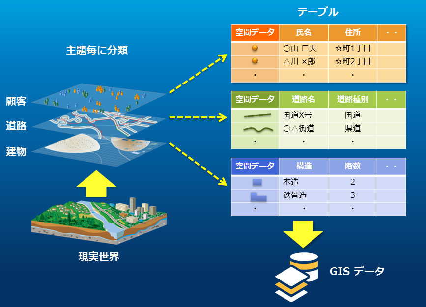

出所：ESRIジャパン「GISとデータモデル」

通常のデータフレームでは、1行が1つの観測値を表す。たとえば、都道府県データであれば、1行が1つの都道府県・1つの年を表している。一方、GISデータでは、それに加えて、場所や形に関する情報が含まれている。

GISが有効なのは、場所に関する問いの多くが、文字や表だけでは表現しにくいからである。たとえば、次のような問いを考えてみよう。

- 日本の原子力発電所は、どの地域に分布しているのか
- 少子化は、日本のどの地域で特に進んでいるのか
- 民営鉄道の路線は、どの地域に集中しているのか

これらの問いに対して、都道府県名や市区町村名を長い表に並べるだけでは、全体像を直感的に把握しにくい。文章で説明しようとすると、地域名を大量に列挙する必要があり、非常に効率が悪い。地図を使えば、地域的な偏り、集中、空白、隣接関係を一目で確認できる。

| データの種類 | 例 | GISでの形 |
| --- | --- | --- |
| 点（point） | 駅、学校、病院、避難所 | 緯度・経度の1点 |
| 線（line） | 道路、鉄道、河川 | 複数の点を結んだ線 |
| 面（polygon） | 都道府県、市区町村、浸水区域 | 線で囲まれた範囲 |

今回扱う行政区域データは、都道府県や市区町村の境界を表す**面（polygon）データ**であり、鉄道データは路線を表す**線（line）データ**である。

GISの発展は、地図による可視化だけでなく、空間計量経済学の発展にもつながっている（Anselin 1988）。多くの場合、GISを使った分析では、**ある時点における地域差**、つまり横断面上の違いを確認する。たとえば、出生率、人口密度、駅の分布、公共施設の立地などを地域ごとに比較する分析である。

発展的には、空間的な関係だけでなく、時間方向の変化や相関を考慮する分析もある。また、衛星から観測された夜間光データを使って、GDPのような経済統計を間接的に推定する研究もある（Chen and Nordhaus 2011; Henderson, Storeygard, and Weil 2012）。このように、GISは地図を描くだけでなく、地域差を分析したり、統計上の測定を補助したりするためにも利用される。

## 1.1 国土数値情報を確認してみる

国土数値情報ダウンロードサイトでは、地形、土地利用、公共施設、交通、災害リスク、都市計画、地価など、**国土に関する基礎的な情報がGISデータとして無償提供**されている。

今回まず確認するのは、汎用性が最も高い [行政区域データ（N03）](https://nlftp.mlit.go.jp/ksj/gml/datalist/KsjTmplt-N03-2026.html) である。行政区域データには、都道府県名、市区町村名などが含まれている。e-Statなどの統計データとの親和性が高いため、都道府県・市区町村データと結合し、地域差を視覚化できる。その他のGISデータは、各自の研究テーマに応じて必要なものをダウンロードすればよい。

ダウンロード手順は次の通りである。

1. [国土数値情報ダウンロードサイト](https://nlftp.mlit.go.jp/ksj/index.html)にアクセスする

2.「行政区域」を選択する

3. 全国または必要な都道府県を選択する
4. ZIPファイルをダウンロードする
5. ZIPファイルを解凍し、`data` フォルダに保存する

最新版の行政区域データは、2026年（令和8年）版であり、データ基準日は2026年1月1日である。ただし、全国版はファイルサイズが大きいため、授業では必要に応じて特定地域のデータを使ってもよい。パソコンのスペックによっては、地図を読み込むのに数分かかる場合がある。

## 1.2 地図データの拡張子

GISデータでは、CSVやExcelとは異なる拡張子がよく使われる。国土数値情報のデータ形式については、[国土数値情報のデータ形式](https://nlftp.mlit.go.jp/ksj/ksj_dataformat.html)でも確認できる。最初に混乱しやすいのは、シェープファイルが1つのファイルではなく、**複数のファイルの組み合わせ**である点である。

| 拡張子 | 意味 | 重要度 | Rでの扱い |
| --- | --- | --- | --- |
| `.shp` | 図形そのものを保存するファイル | 必須 | `st_read()`で読み込む中心ファイル |
| `.shx` | 図形を検索するための索引ファイル | 必須 | `.shp`と同じフォルダに必要 |
| `.dbf` | 属性情報を保存する表ファイル | 必須 | 変数名や地域名が入る |
| `.prj` | 座標参照系を保存するファイル | ほぼ必須 | 地図の位置合わせに重要 |
| `.geojson` | 図形と属性を1つにまとめたテキスト形式 | 形式が別 | `st_read()`で読み込みやすい |
| `.xml` / `.gml` | 地理情報を記述するXML系形式 | 補助的 | 読めるがやや扱いにくい |

重要なのは、`.shp` だけをコピーしてもシェープファイルとしては不十分であるという点である。少なくとも `.shp`、`.shx`、`.dbf` は同じフォルダに置く必要がある。`.prj` がなくても読み込める場合はあるが、座標参照系が分からなくなり、他の地図データと重ねたときに位置がずれる原因になるため、通常は `.prj` も一緒に置く。

## 1.3 座標参照系（CRS）

GISデータには、地球上の位置をどのようなルールで表すかという情報が含まれている。このルールを **座標参照系**（Coordinate Reference System, CRS）という。

同じ日本地図であっても、座標参照系が異なると、重ね合わせたときに位置がずれることがある。初心者の段階では、まず次の2点を覚えればよい。

- `st_crs()` で座標参照系を確認する
- 複数の地図データを重ねるときは、必要に応じて `st_transform()` で座標参照系をそろえる

国土数値情報の行政区域データ（2026年版）と鉄道データ（2025年版）の公式説明では、座標系は **世界測地系（JGD2011）/（B, L）** とされている。ここで、`B` は緯度、`L` は経度を意味する。Rの `sf` では、多くの場合 `EPSG:6668` として扱われる。

| 表記 | 意味 |
| --- | --- |
| JGD2011 | 世界測地系に基づく日本の測地基準 |
| B | 緯度 |
| L | 経度 |
| EPSG:6668 | `sf` で指定しやすいJGD2011のコード |

通常は、`.prj` ファイルやRDSファイルに座標参照系の情報が入っているため、自分で設定する必要はない。地図データを読み込んだあと、`st_crs()` で確認する。

## 1.4 GISとプログラミング

一般的なGIS分析では、ArcGIS のような専用ソフトウェアがよく使われる。一方で、RやPythonを使える場合は、地図データをプログラムに読み込み、これまで学んだデータ処理や可視化の方法をそのまま利用できる。

Rでは、地図データを `sf` オブジェクトとして読み込み、`left_join()` で統計データと結合し、`ggplot2` で可視化できる。重要なのは、地図を描く操作そのものよりも、研究課題に必要な統計データをどの地域単位で整理し、どのようにGISデータと結合するかである。地域差、犯罪のヒートマップ、地震による災害の可視化などには、GISを用いた分析が有効である。

# 2 RでGISデータを読み込む

RでGISデータを扱う代表的なパッケージが [`sf`](https://r-spatial.github.io/sf/) である。`sf` は simple features の略で、地図データを通常のデータフレームに近い感覚で扱うことができる。

```r
rm(list = ls())

# 初回のみインストール
# install.packages("sf")

library(tidyverse)
library(sf)
library(showtext)
```

ここでは、解凍した行政区域データが `./N03-20260101_GML/` に入っているものとする。今回使用する主なファイルは次の通りである。

| ファイル | 意味 |
| --- | --- |
| `N03-20260101_prefecture.shp` | 地図の形 |
| `N03-20260101_prefecture.shx` | 図形の索引 |
| `N03-20260101_prefecture.dbf` | 都道府県名やコードなどの属性表 |
| `N03-20260101_prefecture.prj` | 座標参照系 |
| `N03-20260101_prefecture.geojson` | GeoJSON形式の地図データ |

ただし、地図ファイルは大きく、毎回 shapefile を解析すると時間がかかる。そこで授業では、元の shapefile をあらかじめ都道府県単位に整理して保存した `japan_prefecture_2026.rds` を使用する。

```r
# st_read()を使えば、shapefileを直接読み込むこともできる
pref_map <- readRDS("./japan_prefecture_2026.rds")

# geometry列まで確認したい場合
# head(pref_map)

pref_map %>%
  st_drop_geometry() %>%
  head()
```

| prefecture | code |
| --- | --- |
| 三重県 | 24000 |
| 京都府 | 26000 |
| 佐賀県 | 41000 |
| 兵庫県 | 28000 |
| 北海道 | 01000 |
| 千葉県 | 12000 |

読み込んだオブジェクトは、通常のデータフレームに似ているが、最後に `geometry` という列がある。この `geometry` 列に、地図の形が保存されている。

```r
# structure of CRS
st_crs(pref_map)
```

```
## Coordinate Reference System:
##   User input: JGD2011
##   wkt:
## GEOGCRS["JGD2011",
##     DATUM["Japanese Geodetic Datum 2011",
##         ELLIPSOID["GRS 1980",6378137,298.257222101,
##             LENGTHUNIT["metre",1]]],
##     PRIMEM["Greenwich",0,
##         ANGLEUNIT["degree",0.0174532925199433]],
##     CS[ellipsoidal,2],
##         AXIS["geodetic latitude (Lat)",north,
##             ORDER[1],
##             ANGLEUNIT["degree",0.0174532925199433]],
##         AXIS["geodetic longitude (Lon)",east,
##             ORDER[2],
##             ANGLEUNIT["degree",0.0174532925199433]],
##     USAGE[
##         SCOPE["Horizontal component of 3D system."],
##         AREA["Japan - onshore and offshore."],
##         BBOX[17.09,122.38,46.05,157.65]],
##     ID["EPSG",6668]]
```

`st_crs()` の出力には、この地図データの座標参照系に関する情報が表示される。ここでは、JGD2011に基づく緯度・経度のデータであること、また `EPSG:6668` として扱えることを確認できる。複数の地図データを重ねるときは、この座標参照系がそろっているかを確認する。

元の行政区域データの主な変数は次の通りである。

| 変数名 | 意味 |
| --- | --- |
| `N03_001` | 都道府県名 |
| `N03_002` | 北海道の振興局名 |
| `N03_003` | 郡名 |
| `N03_004` | 市区町村名 |
| `N03_005` | 政令指定都市の行政区名 |
| `N03_007` | 全国地方公共団体コード |
| `geometry` | 地図の形 |

`japan_prefecture_2026.rds` では、都道府県データと結合しやすいように、変数名を次のように整理している。

| 変数名 | 意味 |
| --- | --- |
| `prefecture` | 都道府県名 |
| `code` | 都道府県コード |
| `geometry` | 都道府県境界 |

## 2.1 japan_prefecture_2026.rdsの作成について

国土数値情報の行政区域データには、市区町村などの小さな地域単位の境界が多く含まれている。そのため、元の shapefile を毎回読み込み、地図の形を解析すると時間がかかる。

今回の授業で都道府県別に分析する場合、市区町村などの細かい単位を区別する必要はない。そこで、都道府県名でグループ化し、複数の境界を1つにまとめたうえで、授業用の `japan_prefecture_2026.rds` として保存している。

以下は、そのRDSファイルを作成するためのコードである。Showをクリックして、展開して確認できる。授業中は毎回実行せず、作成済みの `japan_prefecture_2026.rds` を読み込む。

```r
# このブロック実行する必要はない
# st_read()でshapefileを直接読み込む
# pref_map <- st_read("./N03-20260101_GML/N03-20260101_prefecture.shp")
pref_map <- st_read("./N03-20260101_GML/N03-20260101_prefecture.shp", quiet = TRUE) %>%
  # transmute()は、新しい変数を作成し、その変数だけを残す
  transmute(
    prefecture = N03_001,
    code = N03_007
  ) %>%
  group_by(prefecture) %>%
  summarise(
    code = first(code),
    geometry = st_union(geometry),
    .groups = "drop"
  ) %>%
  st_make_valid() %>%
  st_simplify(dTolerance = 0.005, preserveTopology = TRUE)

saveRDS(pref_map, "./japan_prefecture_2026.rds")
```

`st_union()` は、複数のpolygonを1つにまとめる関数である。これにより、市区町村単位や島しょ部に分かれた境界を、都道府県単位の境界に変換できる。`st_simplify()` は地図の形を少し簡略化し、描画を軽くするための関数である。

## 2.2 まず地図だけを描く

`sf` オブジェクトは、`ggplot2` の `geom_sf()` で地図として描くことができる。

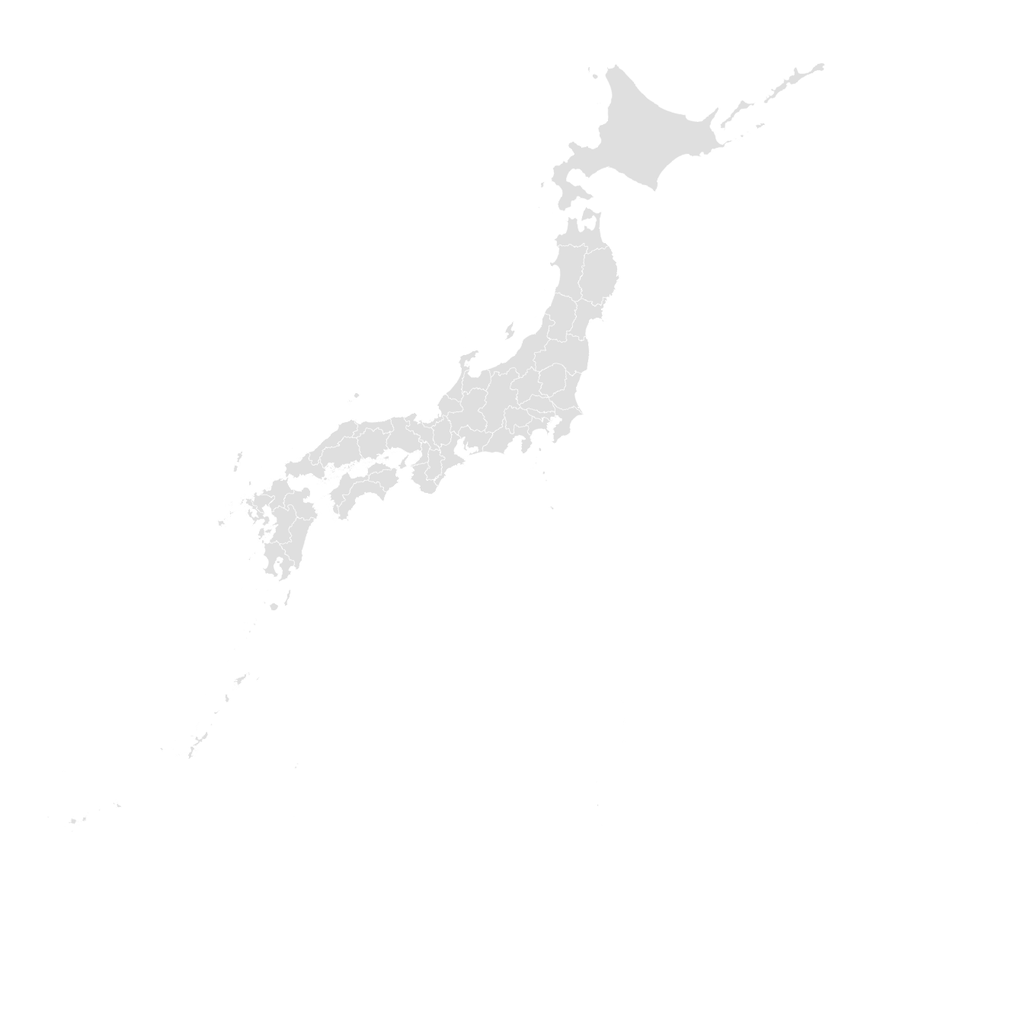

```r
ggplot(pref_map) +
  geom_sf(fill = "gray90", color = "white", linewidth = 0.1) +
  # 軸や背景を消す
  theme_void()
```

ただし、地図を描くだけでは、経済分析や社会分析にはまだ不十分である。多くのGISデータには、境界、地名、コード、路線名などの国土に関する基本情報しか含まれていない。出生率、失業率、所得、人口構成などを分析したい場合は、分析者自身が都道府県データや市区町村データを地図データに結合する必要がある。

# 3 GISで見る少子化

ここでは、都道府県別の合計特殊出生率を地図上で確認するために、地図データとSSDSEデータを結合する。

## 3.1 地図データとSSDSEデータを結合する

前回までに学んだ `left_join()` と考え方は同じである。ここでは、地図データ `pref_map` を左側、SSDSEの2023年データを右側に置き、都道府県名を key として結合する。

結合するときに注意すべき点は、地図データの年と統計データの年が完全には一致していないことである。今回使用する行政区域データは2026年（令和8年）版であり、SSDSEの出生率データは2023年までである。

ただし、都道府県の境界は短期間ではほとんど変化しない。そのため、都道府県単位の分析であれば、2026年版の都道府県地図に2023年の統計データを結合しても、大きな問題は生じにくい。

一方、**市区町村単位**の分析では、合併や分割によって境界や自治体コードが変化するため、特に注意が必要である。たとえば1999年頃から2010年頃にかけて進んだ「平成の大合併」では、市町村数が大きく減少した。そのため、合併前後の市区町村データを扱う場合、古い統計データと新しい地図データがそのまま対応するとは限らない。理想的には、地図データと統計データの地域単位が一致するものだけを使うべきである。ただし、そのためのデータ整理には非常に多くの作業が必要になる。

GISデータと統計データを結合するときは、必ず次の点を確認する必要がある。

- 地図データの基準年
- 統計データの調査年
- 地域名や自治体コードが一致しているか
- 合併・分割・名称変更が起きていないか

```r
# SSDSEは整理した少子化データを使う
japan <- readRDS("./ssdse_birth_rate_2012_2023.rds")

# まずは一時点の地図を作成するため、2023年のみを使う
japan_2023 <- japan %>%
  filter(year == 2023) %>%
  select(
    prefecture,
    population,
    births,
    total_fertility_rate,
    births_per_1000
  )

map_data <- pref_map %>%
  left_join(japan_2023, by = "prefecture")

# geometry列まで確認したい場合
# map_data

map_data %>%
  st_drop_geometry()
```

|  | prefecture | code | population | births | total_fertility_rate | births_per_1000 |
| --- | --- | --- | --- | --- | --- | --- |
| 1 | 三重県 | 24000 | 1727000 | 9524 | 1.29 | 5.514765 |
| 2 | 京都府 | 26000 | 2535000 | 13882 | 1.11 | 5.476134 |
| 3 | 佐賀県 | 41000 | 795000 | 5144 | 1.46 | 6.470440 |
| 4 | 兵庫県 | 28000 | 5370000 | 32615 | 1.29 | 6.073557 |
| 5 | 北海道 | 01000 | 5092000 | 24430 | 1.06 | 4.797722 |
| 6 | 千葉県 | 12000 | 6257000 | 35658 | 1.14 | 5.698897 |
| 7 | 和歌山県 | 30000 | 892000 | 4901 | 1.33 | 5.494395 |
| 8 | 埼玉県 | 11000 | 7331000 | 42108 | 1.14 | 5.743828 |
| 9 | 大分県 | 44000 | 1096000 | 6259 | 1.39 | 5.710766 |
| 10 | 大阪府 | 27000 | 8763000 | 55292 | 1.19 | 6.309711 |

[output cut: 37 more lines]

ここでは都道府県単位で結合しているため確認は比較的容易である。ただし、市区町村単位で分析する場合は、合併や名称変更によって結合できない地域が出ることがあるため、必ず確認する必要がある。

## 3.2 塗り分け地図を作成する

結合ができれば、`geom_sf()` の `aes(fill = 変数名)` を使って、都道府県別の塗り分け地図を作成できる。

連続的な数値を地図上で表す場合は、値の大小が自然に読み取れる色のグラデーションを使う。ここでは、`viridis` 系のカラーマップを使う。`viridis` 系の色は、明るさの変化が比較的なめらかで、色覚多様性にも配慮されているため、統計地図で使いやすい。

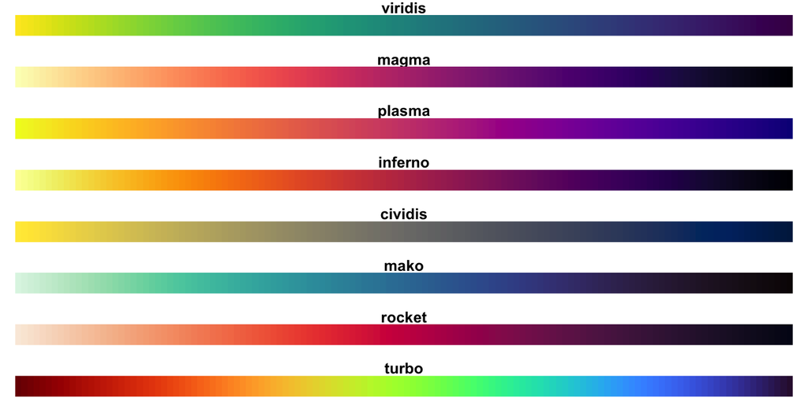

viridis color maps（出所：R package `viridis` / `viridisLite` のカラーマップをもとに作成）

`viridis` 系のカラーマップは、`option` を変えることで切り替えられる。色の名前を覚える必要はなく、`A` から `H` までを変更しながら、地図に合う色を選べばよい。

| option | 名称 |
| --- | --- |
| A | magma |
| B | inferno |
| C | plasma |
| D | viridis |
| E | cividis |
| F | rocket |
| G | mako |
| H | turbo |

```r
# 日本語文字化け防止
font_add_google("Noto Serif JP", "notojp")
showtext_auto()
```

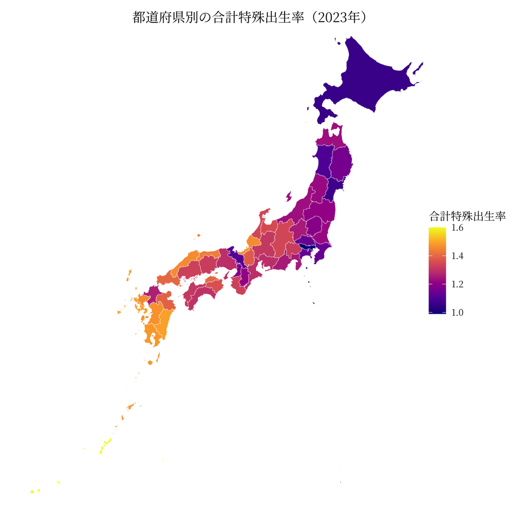

```r
ggplot(map_data) +
  geom_sf(
    aes(fill = total_fertility_rate),
    color = "white",
    linewidth = 0.1
  ) +
  scale_fill_viridis_c(
    option = "C",
    na.value = "gray90"
  ) +
  labs(
    title = "都道府県別の合計特殊出生率（2023年）",
    fill = "合計特殊出生率"
  ) +
  # 海も含めて作図されるため、経緯度の範囲を指定して見やすくする
  coord_sf(
    xlim = c(122, 146),
    ylim = c(24, 46),
    expand = FALSE
  ) +
  theme_void(base_family = "notojp") +
  # 図全体に対してタイトルを中央揃えにする
  theme(
    plot.title = element_text(hjust = 0.5),
    plot.title.position = "plot"
  )
```

塗り分け地図は、地域的な偏りを直感的に示すことができる。一方で、面積が大きい地域が視覚的に目立ちやすいという問題もある。たとえば、北海道は面積が大きいため、地図上で強い印象を与えるが、人口規模とは一致しない。したがって、地図を読むときは、面積と人口の違いに注意する必要がある。

## 3.3 10年間の出生数の変化を見る

1時点の地図だけでなく、2時点を比較することで、地域ごとの変化を可視化できる。ここでは、2013年と2023年の出生数（人口千人あたり）を使い、10年間の変化率を計算する。

```r
birth_change <- japan %>%
  filter(year %in% c(2013, 2023)) %>%
  select(
    prefecture,
    year,
    births_per_1000
  ) %>%
  # パネルデータ分析ではないため、wide形式にして前処理を効率化する
  pivot_wider(
    names_from = year,
    values_from = births_per_1000,
    names_prefix = "births_per_1000_"
  ) %>%
  mutate(
    change_rate = (births_per_1000_2023 - births_per_1000_2013) /
      births_per_1000_2013 * 100
  )

birth_change
```

| prefecture | births_per_1000_2023 | births_per_1000_2013 | change_rate |
| --- | --- | --- | --- |
| 北海道 | 4.797722 | 7.022803 | -31.68366 |
| 青森県 | 4.810811 | 6.825729 | -29.51946 |
| 岩手県 | 4.670679 | 7.106236 | -34.27351 |
| 宮城県 | 5.445230 | 8.122160 | -32.95836 |
| 秋田県 | 3.950766 | 5.882857 | -32.84274 |
| 山形県 | 5.020468 | 7.131993 | -29.60638 |
| 福島県 | 5.104131 | 7.497938 | -31.92620 |
| 茨城県 | 5.273628 | 7.612530 | -30.72437 |
| 栃木県 | 5.249341 | 7.848943 | -33.12040 |
| 群馬県 | 5.231335 | 7.417925 | -29.47711 |

[output cut: 37 more lines]

次に、この変化率を地図データに結合する。

```r
map_change <- pref_map %>%
  left_join(birth_change, by = "prefecture")
```

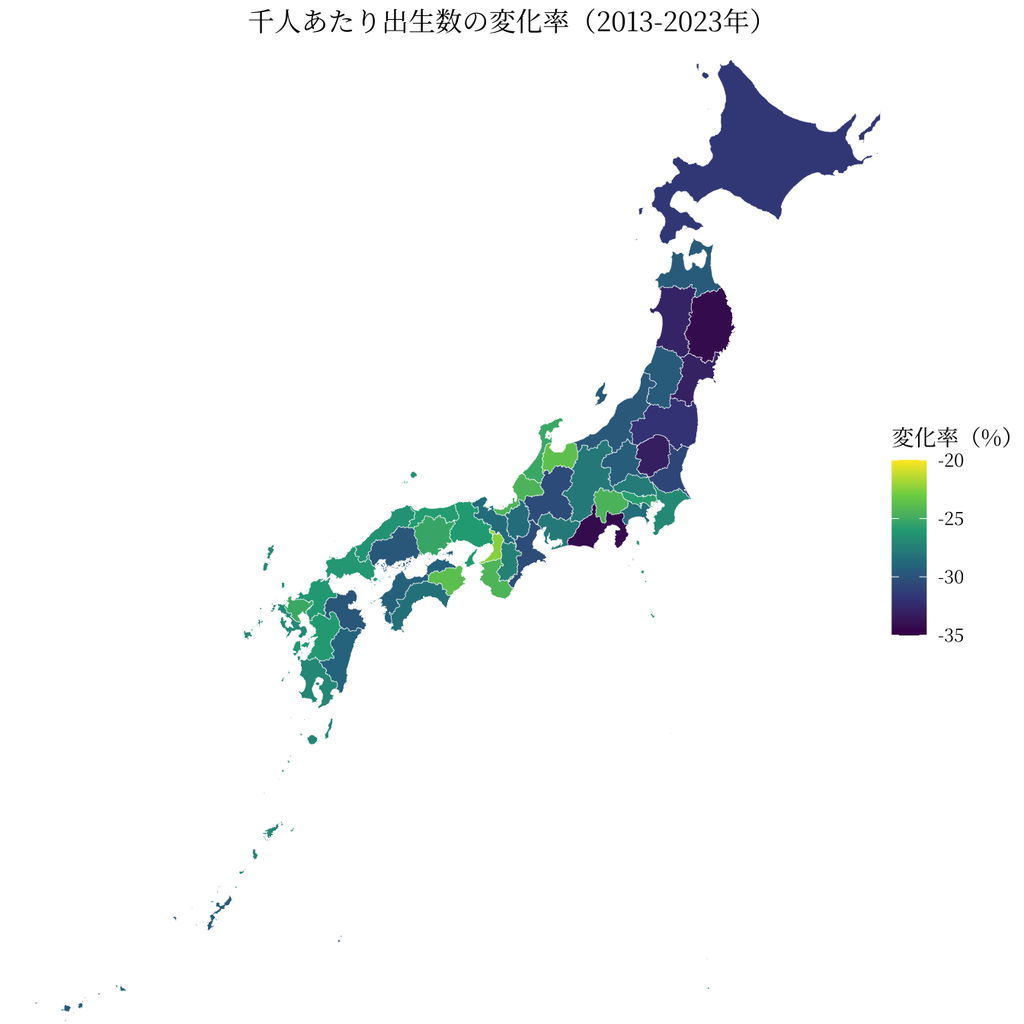

```r
ggplot(map_change) +
  geom_sf(
    aes(fill = change_rate),
    color = "white",
    linewidth = 0.1
  ) +
  scale_fill_viridis_c(
    option = "D",
    limits = c(-35, -20),
    breaks = c(-35, -30, -25, -20),
    na.value = "gray90"
  ) +
  labs(
    title = "千人あたり出生数の変化率（2013-2023年）",
    fill = "変化率（%）"
  ) +
  coord_sf(
    xlim = c(122, 146),
    ylim = c(24, 46),
    expand = FALSE
  ) +
  theme_void(base_family = "notojp") +
  theme(
    plot.title = element_text(hjust = 0.5),
    plot.title.position = "plot"
  )
```

変化率を地図にすると、単に出生率が高い地域・低い地域を見るだけでなく、どの地域で出生数の減少が大きいのかを確認できる。例えば、変化率で見ると、静岡県では少子化の進行がかなり大きいことが分かる。

ここで重要なのは、地図を描くこと自体はそれほど難しくないという点である。GIS分析で大きな負担になるのは、研究課題に合う統計データを整理し、地図データと正しく結合できる形に前処理することである。そのため、分析を始める前に、どの地域単位で何を比較し、最終的にどのような分析結果を得たいのかを考えておくことが重要である。

## 3.4 分析結果を地図に載せる

GIS可視化で地図に載せるものは、出生率や人口密度のような記述統計だけではない。データ分析によって得られた推定量や効果の大きさも、地域単位のデータとして整理すれば、地図データと結合して可視化できる。

たとえば、都道府県別・市区町村別に政策効果、犯罪率への影響、交通インフラの効果などを推定した場合、その推定結果を地域コードや地域名で地図データに結合することで、どの地域で効果が大きいのか、どの地域で効果が小さいのかを比較できる。この意味で、GISは記述統計を見せるためだけでなく、分析結果を空間的に解釈するためにも利用できる。

# 4 鉄道データを可視化する

ここまで扱った行政区域データは、都道府県の範囲を表す**面（polygon）データ**であった。次に、国土数値情報の鉄道データを用いて、鉄道路線を表す**線（line）データ**と、駅を表す**点（point）データ**を可視化する。

今回使用する鉄道データは、国土数値情報の [鉄道データ（N02）](https://nlftp.mlit.go.jp/ksj/gml/datalist/KsjTmplt-N02-2025.html) である。N02には、鉄道路線を表す `RailroadSection` と、駅を表す `Station` のGISデータが含まれている。

授業では、路線データと駅データを読み込みやすい形に整理した `japan_railway_2025.rds` と `japan_station_2025.rds` を使用する。元データを確認する場合は、`N02-25_GML` フォルダの `UTF-8` フォルダにある `N02-25_RailroadSection.shp` や `N02-25_Station.shp` を見るとよい。

| ファイル | 意味 |
| --- | --- |
| `japan_railway_2025.rds` | 処理済み鉄道路線の線データ |
| `japan_station_2025.rds` | 処理済み駅の点データ |
| `N02-25_RailroadSection.shp` | 鉄道路線を表すrawデータ |
| `N02-25_Station.shp` | 駅を表すrawデータ |

## 4.1 鉄道データを読み込む

ここでは、授業用に整理したRDSファイルを読み込む。

```r
railway <- readRDS("./japan_railway_2025.rds")
station <- readRDS("./japan_station_2025.rds")

railway %>%
  st_drop_geometry() %>%
  head()
```

|  | N02_001 | N02_002 | N02_003 | N02_004 |
| --- | --- | --- | --- | --- |
| 1 | 23 | 5 | 沖縄都市モノレール線 | 沖縄都市モノレール |
| 2 | 12 | 5 | いわて銀河鉄道線 | アイジーアールいわて銀河鉄道 |
| 3 | 12 | 5 | いわて銀河鉄道線 | アイジーアールいわて銀河鉄道 |
| 4 | 12 | 5 | いわて銀河鉄道線 | アイジーアールいわて銀河鉄道 |
| 5 | 12 | 5 | いわて銀河鉄道線 | アイジーアールいわて銀河鉄道 |
| 6 | 12 | 5 | いわて銀河鉄道線 | アイジーアールいわて銀河鉄道 |

```r
st_crs(railway)
```

```
## Coordinate Reference System:
##   User input: JGD2011
##   wkt:
## GEOGCRS["JGD2011",
##     DATUM["Japanese Geodetic Datum 2011",
##         ELLIPSOID["GRS 1980",6378137,298.257222101,
##             LENGTHUNIT["metre",1]]],
##     PRIMEM["Greenwich",0,
##         ANGLEUNIT["degree",0.0174532925199433]],
##     CS[ellipsoidal,2],
##         AXIS["geodetic latitude (Lat)",north,
##             ORDER[1],
##             ANGLEUNIT["degree",0.0174532925199433]],
##         AXIS["geodetic longitude (Lon)",east,
##             ORDER[2],
##             ANGLEUNIT["degree",0.0174532925199433]],
##     USAGE[
##         SCOPE["Horizontal component of 3D system."],
##         AREA["Japan - onshore and offshore."],
##         BBOX[17.09,122.38,46.05,157.65]],
##     ID["EPSG",6668]]
```

鉄道データでは、1行が必ずしも1つの路線全体を表すわけではない。**同じ路線が複数の線分に分かれて**保存されているため、同じ路線名や事業者名が何度も出てくることがある。

読み込んだ路線データの主な変数は次の通りである。

| 変数名 | 意味 |
| --- | --- |
| `N02_001` | 鉄道区分 |
| `N02_002` | 事業者種別 |
| `N02_003` | 路線名 |
| `N02_004` | 事業者名 |
| `geometry` | 鉄道路線の形 |

駅データでは、`N02_005` が駅名を表している。

```r
station %>%
  st_drop_geometry() %>%
  head()
```

|  | N02_001 | N02_002 | N02_003 | N02_004 | N02_005 | N02_005c | N02_005g |
| --- | --- | --- | --- | --- | --- | --- | --- |
| 1 | 11 | 2 | 指宿枕崎線 | 九州旅客鉄道 | 二月田 | 010112 | 010112 |
| 2 | 23 | 5 | 沖縄都市モノレール線 | 沖縄都市モノレール | 古島 | 010127 | 010127 |
| 3 | 24 | 5 | 東京臨海新交通臨海線 | ゆりかもめ | お台場海浜公園 | 004091 | 004091 |
| 4 | 24 | 5 | 東京臨海新交通臨海線 | ゆりかもめ | 東京国際クルーズターミナル | 004128 | 004128 |
| 5 | 24 | 5 | 東京臨海新交通臨海線 | ゆりかもめ | テレコムセンター | 004144 | 004144 |
| 6 | 24 | 5 | 東京臨海新交通臨海線 | ゆりかもめ | 汐留 | 003896 | 003887 |

| 変数名 | 意味 |
| --- | --- |
| `N02_003` | 路線名 |
| `N02_004` | 事業者名 |
| `N02_005` | 駅名 |
| `geometry` | 駅の位置 |

`st_geometry_type()` を使うと、読み込んだ地図データが点・線・面のどれであるかを確認できる。

```r
table(st_geometry_type(railway))
```

```
##
##           GEOMETRY              POINT         LINESTRING            POLYGON
##                  0                  0              21933                  0
##         MULTIPOINT    MULTILINESTRING       MULTIPOLYGON GEOMETRYCOLLECTION
##                  0                  0                  0                  0
##     CIRCULARSTRING      COMPOUNDCURVE       CURVEPOLYGON         MULTICURVE
##                  0                  0                  0                  0
##       MULTISURFACE              CURVE            SURFACE  POLYHEDRALSURFACE
##                  0                  0                  0                  0
##                TIN           TRIANGLE
##                  0                  0
```

```r
table(st_geometry_type(station))
```

```
##
##           GEOMETRY              POINT         LINESTRING            POLYGON
##                  0              10234                  0                  0
##         MULTIPOINT    MULTILINESTRING       MULTIPOLYGON GEOMETRYCOLLECTION
##                  0                  0                  0                  0
##     CIRCULARSTRING      COMPOUNDCURVE       CURVEPOLYGON         MULTICURVE
##                  0                  0                  0                  0
##       MULTISURFACE              CURVE            SURFACE  POLYHEDRALSURFACE
##                  0                  0                  0                  0
##                TIN           TRIANGLE
##                  0                  0
```

まず、1つの路線だけを取り出して線データと駅データの形を確認する。ここでは例として、東海道線を表示する。日本地図を指定しない場合、単独の線データと点データとして表示される点に注意しよう。

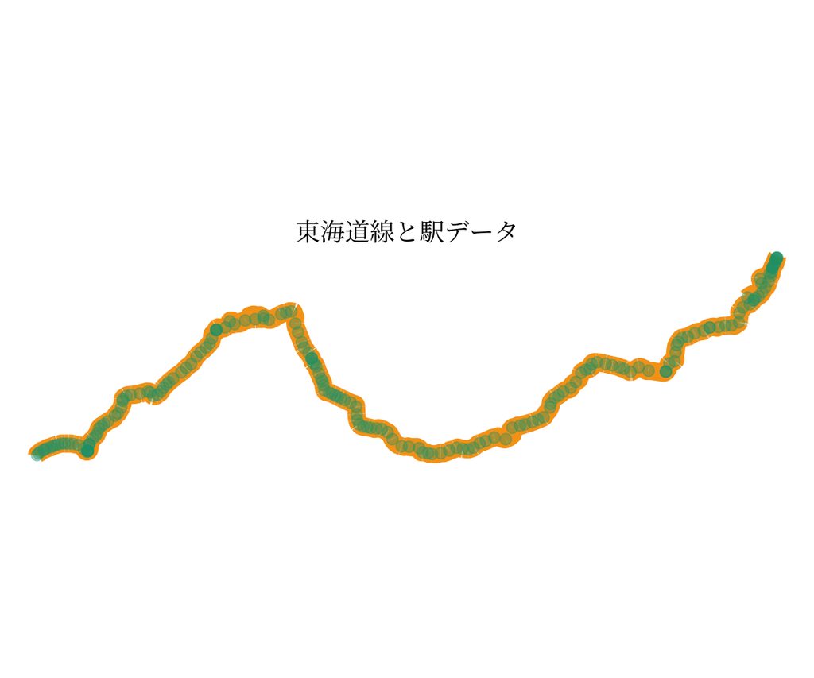

```r
tokaido <- railway %>%
  filter(N02_003 == "東海道線")

tokaido_station <- station %>%
  filter(N02_003 == "東海道線")

ggplot(tokaido) +
  geom_sf(color = "#f6a21a", linewidth = 4.5) +
  geom_sf(
    data = tokaido_station,
    color = "#1b9e77",
    alpha = 0.35,
    size = 2.5
  ) +
  labs(
    title = "東海道線と駅データ"
  ) +
  theme_void(base_family = "notojp") +
  theme(
    plot.title = element_text(hjust = 0.5)
  )
```

## 4.2 鉄道路線を地図に重ねる

鉄道路線は線データであるため、都道府県地図の上に重ねて表示できる。ここでは、`N02_002` の事業者種別を使って色分けする。

今回は、都道府県地図と鉄道データの座標参照系がそろっているため、そのまま重ねて表示できる。もし異なる座標参照系の地図データを重ねる場合は、`st_transform()` でそろえてから描画する。

```r
railway <- railway %>%
  mutate(
    operator_type = case_when(
      N02_002 == "1" ~ "新幹線",
      N02_002 == "2" ~ "JR在来線",
      N02_002 == "3" ~ "公営鉄道",
      N02_002 == "4" ~ "民営鉄道",
      N02_002 == "5" ~ "第三セクター",
      TRUE ~ "不明"
    ),
    operator_type = factor(
      operator_type,
      levels = c("新幹線", "JR在来線", "公営鉄道", "民営鉄道", "第三セクター", "不明")
    )
  )
```

次は日本全土の鉄道路線を、都道府県地図の上に重ねて表示する。

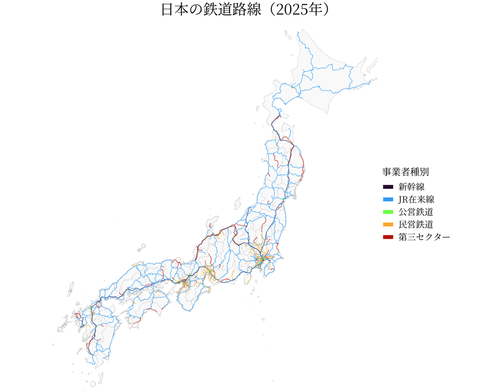

```r
ggplot() +
  # pref_mapは都道府県の面データであり、背景地図として使う
  geom_sf(
    data = pref_map,
    fill = "gray98",
    color = "gray82",
    linewidth = 0.15
  ) +
  # railwayは鉄道路線の線データであり、都道府県地図とは別のobjectである
  geom_sf(
    data = railway,
    aes(color = operator_type),
    linewidth = 0.35,
    alpha = 0.75
  ) +
  scale_color_viridis_d(
    option = "H",
    end = 0.9,
    guide = guide_legend(
      override.aes = list(linewidth = 2.5, alpha = 1)
    )
  ) +
  labs(
    title = "日本の鉄道路線（2025年）",
    color = "事業者種別"
  ) +
  coord_sf(
    xlim = c(128, 146),
    ylim = c(30, 46),
    expand = FALSE
  ) +
  theme_void(base_family = "notojp") +
  theme(
    plot.title = element_text(size = 20, hjust = 0.5),
    plot.title.position = "plot",
    legend.position = "right",
    legend.title = element_text(size = 13),
    legend.text = element_text(size = 12)
  )
```

鉄道データのような線データでは、地域の「範囲」ではなく、ネットワークや接続関係を視覚化できる。行政区域のような面データと重ねることで、どの地域に鉄道路線が集中しているのか、どの地域では路線が少ないのかを確認しやすくなる。ここでは鉄道路線を見やすくするため、沖縄や一部の離島を表示範囲から外し、日本列島の主要部分を少し大きく表示している。

## 4.3 一部の都道府県を抽出してズームイン

同じデータでも、表示範囲を変えると見え方が大きく変わる。次の図では、東京周辺だけを拡大して、鉄道路線が都市部にどの程度集中しているかを確認する。ここでは経緯度を直接指定せず、表示したい都県を選んで地図の範囲を決める。

ただし、東京都には伊豆諸島や小笠原諸島などの離島も含まれる。そのまま使うと表示範囲が大きく広がってしまうため、ここでは各都県で面積が最も大きいpolygonだけを残している。

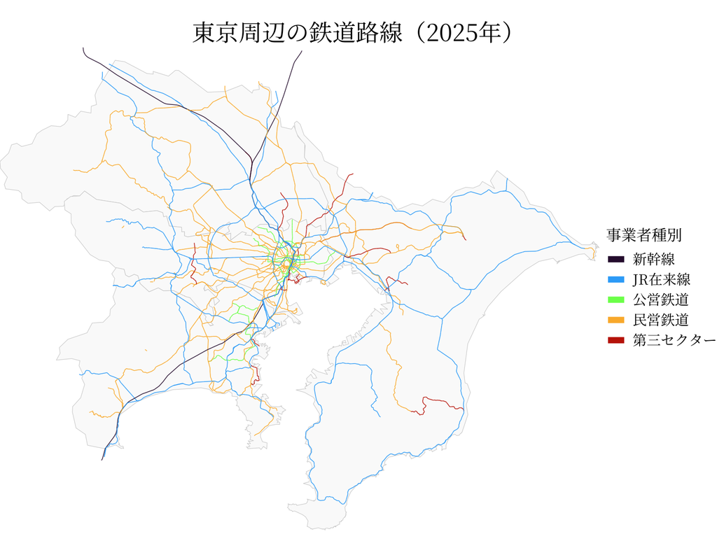

```r
tokyo_area_map <- pref_map %>%
  filter(prefecture %in% c("東京都", "神奈川県", "埼玉県", "千葉県")) %>%
  st_cast("POLYGON") %>%
  mutate(area = st_area(geometry)) %>%
  group_by(prefecture) %>%
  slice_max(area, n = 1) %>%
  ungroup() %>%
  select(-area)

tokyo_area_railway <- railway %>%
  st_filter(st_union(tokyo_area_map))

ggplot() +
  geom_sf(
    data = tokyo_area_map,
    fill = "gray98",
    color = "gray82",
    linewidth = 0.2
  ) +
  geom_sf(
    data = tokyo_area_railway,
    aes(color = operator_type),
    linewidth = 0.3,
    alpha = 0.9
  ) +
  scale_color_viridis_d(
    option = "H",
    end = 0.9,
    guide = guide_legend(
      override.aes = list(linewidth = 2.5, alpha = 1)
    )
  ) +
  labs(
    title = "東京周辺の鉄道路線（2025年）",
    color = "事業者種別"
  ) +
  coord_sf(expand = FALSE) +
  theme_void(base_family = "notojp") +
  theme(
    plot.title = element_text(size = 20, hjust = 0.5),
    plot.title.position = "plot",
    legend.position = "right",
    legend.title = element_text(size = 13),
    legend.text = element_text(size = 12)
  )
```

# 5 GIS分析の注意点

## 5.1 よくある失敗

GISデータを扱うときには、次のような問題がよく起きる。

| 問題 | 原因 | 対処 |
| --- | --- | --- |
| ファイルが読み込めない | `.shp` だけを移動した | `.shp`, `.shx`, `.dbf`, `.prj` を同じフォルダに置く |
| 地図がずれる | CRSが異なる | `st_crs()` で確認し、`st_transform()` でそろえる |
| 結合後にNAが出る | keyが一致していない | 都道府県名やコードを確認する |
| 処理が重い | 全国版の地図が細かすぎる | 必要な地域だけ使う、行政区域をまとめる、`st_simplify()` を使う、またはRDSとして保存する |

特に重要なのは、**結合の key を確認すること**である。表データの結合と同じように、地図データでも key が一致していなければ正しい地図は作成できない。

また、GIS分析では大きな地図データを扱うと、処理に非常に時間がかかることがある。全国版の市区町村境界のように細かい地図をそのまま使うと、読み込みや描画だけで10分以上かかったり、多くのwarningやerrorが出たりする場合もある。そのため、分析に不要な細かい行政区域は、前処理の段階でまとめておくことが重要である。たとえば、都道府県単位で分析する場合は、市区町村境界を都道府県境界に統合し、処理済みのRDSファイルとして保存しておくと、授業中や分析中の作業がかなり軽くなる。

## 5.2 研究のヒント

良い研究は、良い問いから生まれる。

例えば、

- 一日のうち、どの時間帯に犯罪率が最も高いのだろうか。
- 犯罪者は何月に凶暴になりやすいのだろうか。そこに季節性は存在するのだろうか。
- 性的人身売買はどの地域に集中しているのだろうか。

[figure not shown]

性的人身売買事件の地理的分布の例（出所：Palantir）

犯罪ビッグデータを分析することで、このような社会的に重要な問いに答えることができる。

たとえば、Zhuang and Mateu（2019）は、犯罪事件を「いつ・どこで発生した点」として扱い、時空間Hawkes型点過程モデルを用いて犯罪の発生パターンを分析している。この研究では、犯罪の発生を、日周期・週周期などをもつ背景発生率と、過去の犯罪事件によって近い時間・近い場所で次の犯罪が起きやすくなる誘発効果に分けて考えている。つまり、GISで犯罪地点を地図に表示するだけでなく、犯罪が時間的・空間的にどのように集中し、連鎖するのかまで分析できる。

また、ここから得られる知見は、防犯政策だけでなく、住宅市場の分析にも応用できる。例えば、安全性は住宅価格や居住地選択に大きな影響を与えるためである。

データ分析とは単なる集計作業ではない。社会の中に存在する規則性を発見し、人々の意思決定に役立つ知見を生み出す作業である。犯罪ビッグデータを使って研究する場合も、コードを書く前に、まず自分が何を問いたいのかを書き出すことが重要である。

# 6 参考資料

- Anselin, L. (1988). *Spatial Econometrics: Methods and Models*. Dordrecht: Kluwer Academic Publishers.  
  https://doi.org/10.1007/978-94-015-7799-1
- Chen, X., and Nordhaus, W. D. (2011). “Using luminosity data as a proxy for economic statistics.” *Proceedings of the National Academy of Sciences*, 108(21), 8589-8594.  
  https://doi.org/10.1073/pnas.1017031108
- Henderson, J. V., Storeygard, A., and Weil, D. N. (2012). “Measuring Economic Growth from Outer Space.” *American Economic Review*, 102(2), 994-1028.  
  https://doi.org/10.1257/aer.102.2.994
- Zhuang, J., and Mateu, J. (2019). “A Semiparametric Spatiotemporal Hawkes-Type Point Process Model with Periodic Background for Crime Data.” *Journal of the Royal Statistical Society Series A: Statistics in Society*, 182(3), 919-942.  
  https://doi.org/10.1111/rssa.12429